# Project 1

# Emma Potzner and Ryn Mundy

# 04/06/2020

# Step 2: Data Analysis and Writeup

In this project, we will explore this Housing data by using price as the response variable and trying to find how the other variables can be used to predict the price of a House.

Below, we have imported the data.

```r
library(readxl)
housing <- read_excel("Housing.xlsx")
head(housing)
```

```
## # A tibble: 6 x 11
##      id price  size   lot  bath bedrooms yearbuilt agestandardized garagesize
##   <dbl> <dbl> <dbl> <dbl> <dbl>    <dbl>     <dbl>           <dbl>      <dbl>
## 1     1  388   2.18     4     3        4      1940            -3            0
## 2     2  450   2.05     5     3        4      1957            -1.3          2
## 3     3  386   2.11     5     2        4      1955            -1.5          2
## 4     4  350   1.44     6     1        2      1956            -1.4          1
## 5     5  156.  1.8      1     2        4      1994             2.4          1
## 6     6  220   1.96     5     2        3      1940            -3            1
## # … with 2 more variables: status <chr>, elem <chr>
```

# Data Summary:

Now, we will look at the data itself to make sure it is in a good condition to be used for our modeling that will come later. Lukcily, no data points are missing, so there is no need to remove any data because of that. One point that strikes me as unsual based upon reading the data is point [74] because it has a lot size of 11 when all other lot sizes in this data are size 8 and below, with most being between sizes 1 and 5. The price of the house for this point is the second most expensive house, so we may explore lot size as a predicting factor later on because of this. One thing about this data that I believe needs clarification is the amount of bathrooms. Any number that is not an integer is listed with a .1 , whereas it was to my understanding that a half bathroom would be counted with a .5 (ex. 2.5 instead of 2.1 bathrooms). This may be a numerical error that we should change by adding a new column with the .5 decimal to indicate half bathrooms instead. I also find it unusual that the house with the most amount of bedrooms, data point [35], has what I would consider to be small square footage for a house with 6 bedrooms. It also has a very low age standard size, meaning that the house was small relative to the other houses built at the time. This could mean there is an input error for the number of bedrooms for this house or some other reason it has 6 bedrooms with small square footage. We will keep our eye on this point to see how it affects the data later. The final point that I will mention is that the most expensive house, point [2] at $450,000 , has an age standard size score of -1.3, meaning it is more than one standard deviation below the mean. This is unexpected for such an expensive house, but it leads me to believe that size of the house is definitely not the only predicting factor for a house’s price.

# Exploratory Data Analysis:

Below are the ranges, mins, and maxes for each variable.

```r
sapply(housing, range)
```

```
##      id   price   size    lot  bath  bedrooms yearbuilt agestandardized
## [1,] "1"  "155.5" "1.44"  "1"  "1"   "2"      "1905"    "-6.5"
## [2,] "76" "450"   "2.896" "11" "3.1" "6"      "2005"    "3.5"
##      garagesize status elem
## [1,] "0"        "act"  "adams"
## [2,] "3"        "sld"  "parker"
```

```r
sapply(housing, min)
```

```
##              id           price            size             lot            bath
##             "1"         "155.5"          "1.44"             "1"             "1"
##        bedrooms       yearbuilt agestandardized      garagesize          status
##             "2"          "1905"          "-6.5"             "0"           "act"
##            elem
##         "adams"
```

```r
sapply(housing, max)
```

```
##              id           price            size             lot            bath
##            "76"           "450"         "2.896"            "11"           "3.1"
##        bedrooms       yearbuilt agestandardized      garagesize          status
##             "6"          "2005"           "3.5"             "3"           "sld"
##            elem
##        "parker"
```

# Exploratory Data Analysis:

First, we will manipulate the data a little bit depending on the observations made above. We will change both the status and the elementary school district to be numeric. This will help in being able to use these as predictor variables. * status will be 1-active, 2-pending, and 3-sold * elem will be 1-Adams, 2-Crest, 3-Edge, 4-Edison, 5-Harris, 6-Parker

```r
housing$elem <- as.numeric(as.factor(housing$elem))
housing$status <- as.numeric(as.factor(housing$status))
#head(housing)
#sapply(housing, class)
```

*Below, we are also changing the bathroom decimal value to 0.5 instead of 0.1 to make more sense to anyone who may view the data without prior knowledge of what the values may mean.*

```r
housing$bath[c(7,31,52,64,73) ] <- 1.5
housing$bath[c(9,10,13,18,19,33,38,39,42,46,48,57,58,67,69,72) ] <- 2.5
housing$bath[c(41,54,59,60,61,62,63) ] <- 3.5
housing$bath[c(7,31,52,64,73) ]
```

```
## [1] 1.5 1.5 1.5 1.5 1.5
```

```r
housing$bath[c(9,10,13,18,19,33,38,39,42,46,48,57,58,67,69,72) ]
```

```
##  [1] 2.5 2.5 2.5 2.5 2.5 2.5 2.5 2.5 2.5 2.5 2.5 2.5 2.5 2.5 2.5 2.5
```

```r
housing$bath[c(41,54,59,60,61,62,63) ]
```

```
## [1] 3.5 3.5 3.5 3.5 3.5 3.5 3.5
```

To start with our Exploratory Data Analysis, we will create a matrix to have a visual of how the variables may relate to each other.

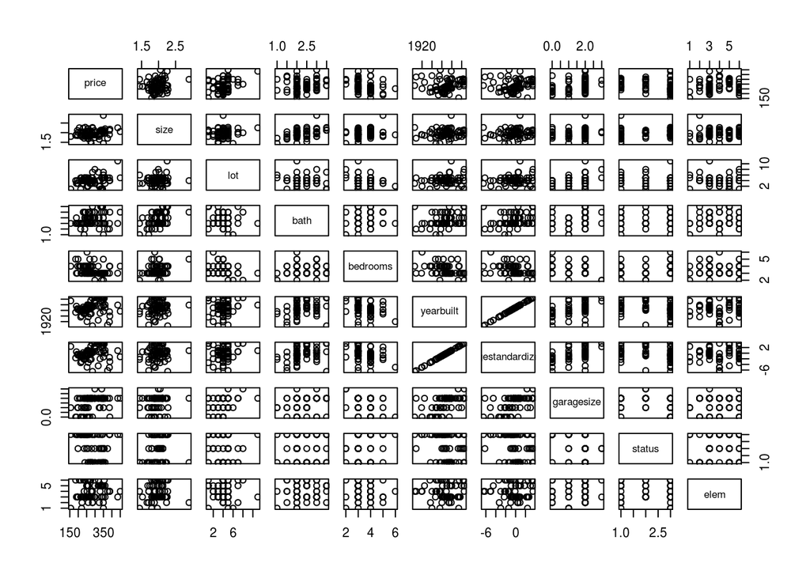

```r
pairs(housing[,2:11])
```

```r
cor(housing[,2:11])
```

```
##                       price       size         lot        bath    bedrooms
## price            1.00000000 0.20143783  0.24423228  0.19755760 -0.28619746
## size             0.20143783 1.00000000  0.04079199  0.46251016  0.23845303
## lot              0.24423228 0.04079199  1.00000000 -0.23302415 -0.21382977
## bath             0.19755760 0.46251016 -0.23302415  1.00000000  0.07376720
## bedrooms        -0.28619746 0.23845303 -0.21382977  0.07376720  1.00000000
## yearbuilt        0.15412476 0.17656934 -0.03933975  0.36536037 -0.36315062
## agestandardized  0.15412476 0.17656934 -0.03933975  0.36536037 -0.36315062
## garagesize       0.35838608 0.17315776  0.23581664  0.19576152 -0.40380395
## status          -0.25124114 0.11922561 -0.05222278 -0.10280084  0.20454371
## elem             0.06298451 0.13144356 -0.06277219  0.08025316  0.01710781
##                   yearbuilt agestandardized  garagesize      status        elem
## price            0.15412476      0.15412476  0.35838608 -0.25124114  0.06298451
## size             0.17656934      0.17656934  0.17315776  0.11922561  0.13144356
## lot             -0.03933975     -0.03933975  0.23581664 -0.05222278 -0.06277219
## bath             0.36536037      0.36536037  0.19576152 -0.10280084  0.08025316
## bedrooms        -0.36315062     -0.36315062 -0.40380395  0.20454371  0.01710781
## yearbuilt        1.00000000      1.00000000  0.53718464 -0.29966979  0.12813721
## agestandardized  1.00000000      1.00000000  0.53718464 -0.29966979  0.12813721
## garagesize       0.53718464      0.53718464  1.00000000 -0.33308182  0.06939738
## status          -0.29966979     -0.29966979 -0.33308182  1.00000000 -0.01552671
## elem             0.12813721      0.12813721  0.06939738 -0.01552671  1.00000000
```

# Initial Modeling:

*Testing which predictors are significant with different, multiple regression models.*

```r
mrm <- lm(price ~ . - id, data = housing)
summary(mrm)
```

```
##
## Call:
## lm(formula = price ~ . - id, data = housing)
##
## Residuals:
##     Min      1Q  Median      3Q     Max
## -97.752 -36.998  -9.052  38.485 152.264
##
## Coefficients: (1 not defined because of singularities)
##                  Estimate Std. Error t value Pr(>|t|)
## (Intercept)     1190.0810   695.2326   1.712   0.0916 .
## size              56.2690    36.9025   1.525   0.1320
## lot                5.8999     4.2351   1.393   0.1682
## bath              18.0547    13.2361   1.364   0.1771
## bedrooms         -22.3264    10.4063  -2.145   0.0355 *
## yearbuilt         -0.5111     0.3547  -1.441   0.1542
## agestandardized        NA         NA      NA       NA
## garagesize        14.1504    10.7601   1.315   0.1930
## status           -12.7982     7.6773  -1.667   0.1002
## elem               2.0199     4.4942   0.449   0.6546
## ---
## Signif. codes:  0 '***' 0.001 '**' 0.01 '*' 0.05 '.' 0.1 ' ' 1
##
## Residual standard error: 54.25 on 67 degrees of freedom
## Multiple R-squared:  0.2777, Adjusted R-squared:  0.1915
## F-statistic: 3.221 on 8 and 67 DF,  p-value: 0.003718
```

```r
mrm1 <- lm(price~ size + lot + bedrooms + bath + yearbuilt + garagesize + status + elem, data=housing)
summary(mrm1)
```

```
##
## Call:
## lm(formula = price ~ size + lot + bedrooms + bath + yearbuilt +
##     garagesize + status + elem, data = housing)
##
## Residuals:
##     Min      1Q  Median      3Q     Max
## -97.752 -36.998  -9.052  38.485 152.264
##
## Coefficients:
##              Estimate Std. Error t value Pr(>|t|)
## (Intercept) 1190.0810   695.2326   1.712   0.0916 .
## size          56.2690    36.9025   1.525   0.1320
## lot            5.8999     4.2351   1.393   0.1682
## bedrooms     -22.3264    10.4063  -2.145   0.0355 *
## bath          18.0547    13.2361   1.364   0.1771
## yearbuilt     -0.5111     0.3547  -1.441   0.1542
## garagesize    14.1504    10.7601   1.315   0.1930
## status       -12.7982     7.6773  -1.667   0.1002
## elem           2.0199     4.4942   0.449   0.6546
## ---
## Signif. codes:  0 '***' 0.001 '**' 0.01 '*' 0.05 '.' 0.1 ' ' 1
##
## Residual standard error: 54.25 on 67 degrees of freedom
## Multiple R-squared:  0.2777, Adjusted R-squared:  0.1915
## F-statistic: 3.221 on 8 and 67 DF,  p-value: 0.003718
```

```r
mrm2 <- lm(price ~ bedrooms  + size + lot, data = housing)
summary(mrm2)
```

```
##
## Call:
## lm(formula = price ~ bedrooms + size + lot, data = housing)
##
## Residuals:
##      Min       1Q   Median       3Q      Max
## -113.258  -44.153   -6.192   43.378  165.910
##
## Coefficients:
##             Estimate Std. Error t value Pr(>|t|)
## (Intercept)  199.531     64.414   3.098  0.00278 **
## bedrooms     -25.776      9.210  -2.799  0.00658 **
## size          76.630     31.262   2.451  0.01667 *
## lot            6.053      3.993   1.516  0.13397
## ---
## Signif. codes:  0 '***' 0.001 '**' 0.01 '*' 0.05 '.' 0.1 ' ' 1
##
## Residual standard error: 55.59 on 72 degrees of freedom
## Multiple R-squared:  0.185,  Adjusted R-squared:  0.1511
## F-statistic: 5.449 on 3 and 72 DF,  p-value: 0.001967
```

```r
mrm3 <- lm(price ~ size + size:lot + bath:bedrooms, data = housing)
summary(mrm3)
```

```
##
## Call:
## lm(formula = price ~ size + size:lot + bath:bedrooms, data = housing)
##
## Residuals:
##     Min      1Q  Median      3Q     Max
## -101.92  -43.88   -6.95   49.18  155.45
##
## Coefficients:
##               Estimate Std. Error t value Pr(>|t|)
## (Intercept)    174.146     64.645   2.694  0.00878 **
## size            45.955     39.775   1.155  0.25176
## size:lot         3.838      2.082   1.844  0.06933 .
## bath:bedrooms   -1.117      2.972  -0.376  0.70807
## ---
## Signif. codes:  0 '***' 0.001 '**' 0.01 '*' 0.05 '.' 0.1 ' ' 1
##
## Residual standard error: 58.55 on 72 degrees of freedom
## Multiple R-squared:  0.09582,    Adjusted R-squared:  0.05815
## F-statistic: 2.544 on 3 and 72 DF,  p-value: 0.06286
```

# Model Modification:

```r
library(car)
vif(mrm2)
```

```
## bedrooms     size      lot
## 1.119721 1.070305 1.057814
```

*VIF result shows no reason to suspect that these variables should be removed from the model. If the results showed numbers between 5 and 10, this would be cause for concern.*

# Conclusions:

```r
#95% confidence interbals for each β coefficient
confint(mrm2)
```

```
##                  2.5 %     97.5 %
## (Intercept)  71.123104 327.938623
## bedrooms    -44.136057  -7.415614
## size         14.310748 138.949995
## lot          -1.907747  14.013194
```

-According to the R-squared value from our regession model “mrm2”, 18.5% of the variance in the price is explained by the bedrooms, size, and lot.

```r
#Testing 95% confidence interval
new.house <- data.frame(bedrooms=2, size=1.000, lot=1)
predict(mrm2, new.house, interval = "confidence")
```

```
##        fit      lwr      upr
## 1 230.6623 165.1699 296.1547
```

```r
#Testing 95% prediction interval
predict(mrm2, new.house, interval = "predict")
```

```
##        fit      lwr      upr
## 1 230.6623 101.9412 359.3834
```